# Food and You analyses_enviroment impact 27112023

Constanza Avalos

2023-11-27

## Food and You 2: Waves 1-6, 2020-2023

This is an analysis of the questions on the environmental impact of food from the “Food and You” survey, wave 4.

The Food and You Surveys (2010-2018), and Food and You 2 (2020- ) are biennial, cross-sectional surveys of adults aged 16 years and over living in England, Wales and Northern Ireland, commissioned by the Food Standards Agency (FDA). Food and You provides data about the prevalence of different attitudes, reported behaviour and knowledge about ways in which food is purchased, stored, prepared and eaten.

In 2018, the FSA’s Advisory Committee for Social Science (ACSS) recommended that Food and You and the Public Attitudes Tracker were replaced with a new ‘push-to-web’ survey, Food and You 2, which was commissioned in 2019 with data collection commencing in July 2020. Due to differences in the survey methodologies, comparisons cannot be made between the earlier Food and You surveys, or the Public Attitudes Tracker, and Food and You 2. Therefore Food and You 2, 2020 is the start of a new data time series.

The topics cover in the survey are: Trust in FSA and the food supply chain, Concerns about food, Food security, Food shopping and labelling, Online platforms, Food-related behaviours and eating habits. Food and You 2-Wave 4 has added the module “Food shopping: sustainability and environmental impact”, which contains questions about eco-labels.

Technical features:

Dates of fieldwork: Wave 1: 28 July - 6 October 2020; Wave 2: 20 November 2020 - 21 January 2021; Wave 3: 28 April - 25 June 2021; Wave 4: 18 October 2021 - 10 January 2022; Wave 5: 26 April - 24 July 2022. Wave 6: 12 October 2022 - 10 January 2023

Observation units: Individuals

Number of units: Wave 1: 9,319 cases; Wave 2: 5,900; Wave 3: 6,271; Wave 4: 5,796; Wave 5: 6,770; Wave 6: 5,991

Method of data collection: a) Self-administered questionnaire: Web-based (CAWI) and b) Self-administered questionnaire: Paper

Time dimensions: Repeated cross-sectional study

Sampling procedures: Multi-stage stratified random sample

Weighting: Weighting used. See documentation for details

```r
library(readxl)
Wave_4 <- read_excel("C:/Users/const/OneDrive/Desktop/PhD/R/Food and You 2 Waves 1-6, 2020-2023/Wave 4.xlsx")
```

## Dataset descriptives

```r
head(Wave_4)
```

```
## # A tibble: 6 × 1,225
##   SERIALID mode_dv country Region_dv   imd urban nadults nchildren ntotalhh
##      <dbl>   <dbl>   <dbl>     <dbl> <dbl> <dbl>   <dbl>     <dbl>    <dbl>
## 1 24000011       1       3        11     5     2       1         0        1
## 2 24000022       3       1         8     5     1       2         0        2
## 3 24000032       1       1         5     3     2       2         0        2
## 4 24000041       1       1         3     3     1       2         2        4
## 5 24000051       1       1         1     4     2       2         0        2
## 6 24000061       2       1         7     5     1       1         0        1
## # ℹ 1,216 more variables: AgeBand_dv <dbl>, gender_dv <dbl>, news1 <dbl>,
## #   news2 <dbl>, news3 <dbl>, news4 <dbl>, news5 <dbl>, news6 <dbl>,
## #   news7 <dbl>, news8 <dbl>, news9 <dbl>, news10 <dbl>, news11 <dbl>,
## #   news_net <dbl>, veg <dbl>, vegtime <dbl>, foodreac <dbl>,
## #   Reacsourc_any1 <dbl>, Reacsourc_any2 <dbl>, Reacsourc_any3 <dbl>,
## #   Reacsourc_any4 <dbl>, Reacsourc_any5 <dbl>, reactype_any1 <dbl>,
## #   reactype_any2 <dbl>, reactype_any3 <dbl>, reactype_any4 <dbl>, …
```

```r
str((Wave_4))
```

```
## tibble [5,796 × 1,225] (S3: tbl_df/tbl/data.frame)
##  $ SERIALID               : num [1:5796] 2.4e+07 2.4e+07 2.4e+07 2.4e+07 2.4e+07 ...
##  $ mode_dv                : num [1:5796] 1 3 1 1 1 2 1 2 3 1 ...
##  $ country                : num [1:5796] 3 1 1 1 1 1 2 1 1 1 ...
##  $ Region_dv              : num [1:5796] 11 8 5 3 1 7 10 2 2 7 ...
##  $ imd                    : num [1:5796] 5 5 3 3 4 5 4 2 5 5 ...
##  $ urban                  : num [1:5796] 2 1 2 1 2 1 1 1 2 2 ...
##  $ nadults                : num [1:5796] 1 2 2 2 2 1 2 1 2 2 ...
##  $ nchildren              : num [1:5796] 0 0 0 2 0 0 0 0 0 3 ...
##  $ ntotalhh               : num [1:5796] 1 2 2 4 2 1 2 1 2 5 ...
##  $ AgeBand_dv             : num [1:5796] 6 5 7 3 4 7 3 6 7 3 ...
##  $ gender_dv              : num [1:5796] 1 1 2 1 1 1 2 2 -99 1 ...
##  $ news1                  : num [1:5796] 1 1 1 1 1 0 1 1 1 1 ...
##  $ news2                  : num [1:5796] 1 1 0 1 1 1 0 0 0 1 ...
##  $ news3                  : num [1:5796] 0 1 1 0 0 1 0 0 1 1 ...
```

[output cut: 86 more lines]

```r
library(skimr)
skim(Wave_4, mode_dv, country, Region_dv, imd, urban, nadults, nchildren, ntotalhh, AgeBand_dv, gender_dv, defra9_1, defra10_1, defra4_2, defra5_2)
```

Data summary

| Name | Wave_4 |
| --- | --- |
| Number of rows | 5796 |
| Number of columns | 1225 |
| _______________________ |  |
| Column type frequency: |  |
| numeric | 14 |
| ________________________ |  |
| Group variables | None |

**Variable type: numeric**

| skim_variable | n_missing | complete_rate | mean | sd | p0 | p25 | p50 | p75 | p100 | hist |
| --- | --- | --- | --- | --- | --- | --- | --- | --- | --- | --- |
| mode_dv | 0 | 1 | 1.53 | 0.77 | 1 | 1 | 1 | 2 | 3 | ▇▁▂▁▂ |
| country | 0 | 1 | 1.76 | 0.85 | 1 | 1 | 1 | 3 | 3 | ▇▁▃▁▅ |
| Region_dv | 0 | 1 | 7.92 | 3.16 | 1 | 6 | 9 | 11 | 11 | ▂▂▂▂▇ |
| imd | 0 | 1 | 3.24 | 1.38 | 1 | 2 | 3 | 4 | 5 | ▅▆▆▇▇ |
| urban | 0 | 1 | 1.31 | 0.46 | 1 | 1 | 1 | 2 | 2 | ▇▁▁▁▃ |
| nadults | 0 | 1 | 0.59 | 11.80 | -99 | 2 | 2 | 2 | 5 | ▁▁▁▁▇ |
| nchildren | 0 | 1 | -0.20 | 6.68 | -99 | 0 | 0 | 0 | 5 | ▁▁▁▁▇ |
| ntotalhh | 0 | 1 | 0.55 | 13.02 | -99 | 2 | 2 | 3 | 5 | ▁▁▁▁▇ |
| AgeBand_dv | 0 | 1 | 2.81 | 12.61 | -99 | 3 | 4 | 6 | 7 | ▁▁▁▁▇ |
| gender_dv | 0 | 1 | 0.65 | 9.18 | -99 | 1 | 2 | 2 | 2 | ▁▁▁▁▇ |
| defra9_1 | 0 | 1 | 1.30 | 5.32 | -99 | 1 | 2 | 2 | 5 | ▁▁▁▁▇ |
| defra10_1 | 0 | 1 | 2.57 | 5.47 | -99 | 2 | 3 | 4 | 6 | ▁▁▁▁▇ |
| defra4_2 | 0 | 1 | 2.72 | 5.45 | -99 | 2 | 4 | 5 | 6 | ▁▁▁▁▇ |
| defra5_2 | 0 | 1 | 2.45 | 5.24 | -99 | 2 | 3 | 4 | 6 | ▁▁▁▁▇ |

## How important is it to you to buy food which has a low environmental impact?

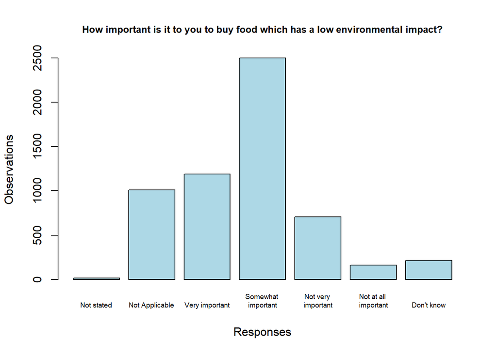

```r
barplot(table(Wave_4$defra9_1),
        main = "How important is it to you to buy food which has a low environmental impact?",
        xlab = "Responses",
        ylab = "Observations",
        names.arg = c("Not stated", "Not Applicable", "Very important", "Somewhat \nimportant", "Not very \nimportant", "Not at all \nimportant", "Don’t know"),
        col = "lightblue",
        cex.main=0.8,
        cex.names=0.6)
```

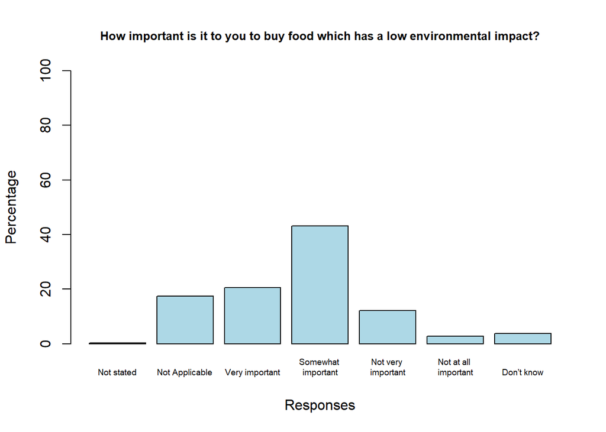

```r
library(scales)
barplot(table(Wave_4$defra9_1)/length(Wave_4$defra9_1) * 100,
        main = "How important is it to you to buy food which has a low environmental impact?",
        xlab = "Responses",
        ylab = "Percentage",
        ylim = c(0, 100),
        names.arg = c("Not stated", "Not Applicable", "Very important", "Somewhat \nimportant", "Not very \nimportant", "Not at all \nimportant", "Don’t know"),
        col = "lightblue",
        cex.main=0.8,
        cex.names=0.6)
```

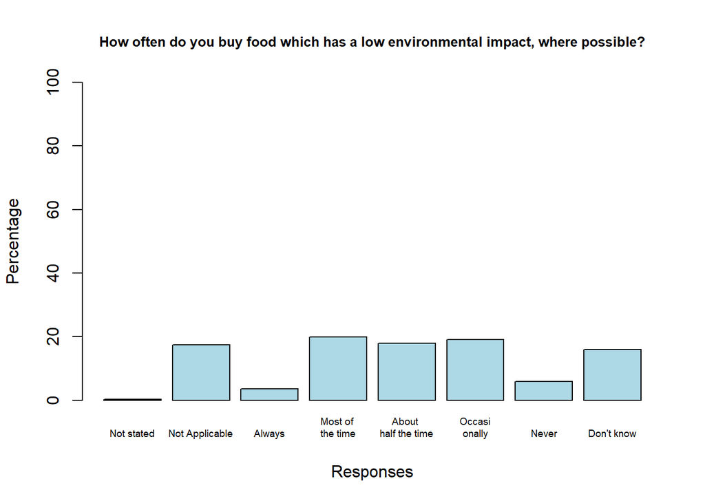

```r
barplot(table(Wave_4$defra10_1)/length(Wave_4$defra10_1) * 100,
        main = "How often do you buy food which has a low environmental impact, where possible?",
        xlab = "Responses",
        ylab = "Percentage",
        ylim = c(0, 100),
        names.arg = c("Not stated", "Not Applicable", "Always", "Most of \nthe time", "About \nhalf the time", "Occasi\nonally", "Never", "Don’t know"),
        col = "lightblue",
        cex.main=0.8,
        cex.names=0.6)
```

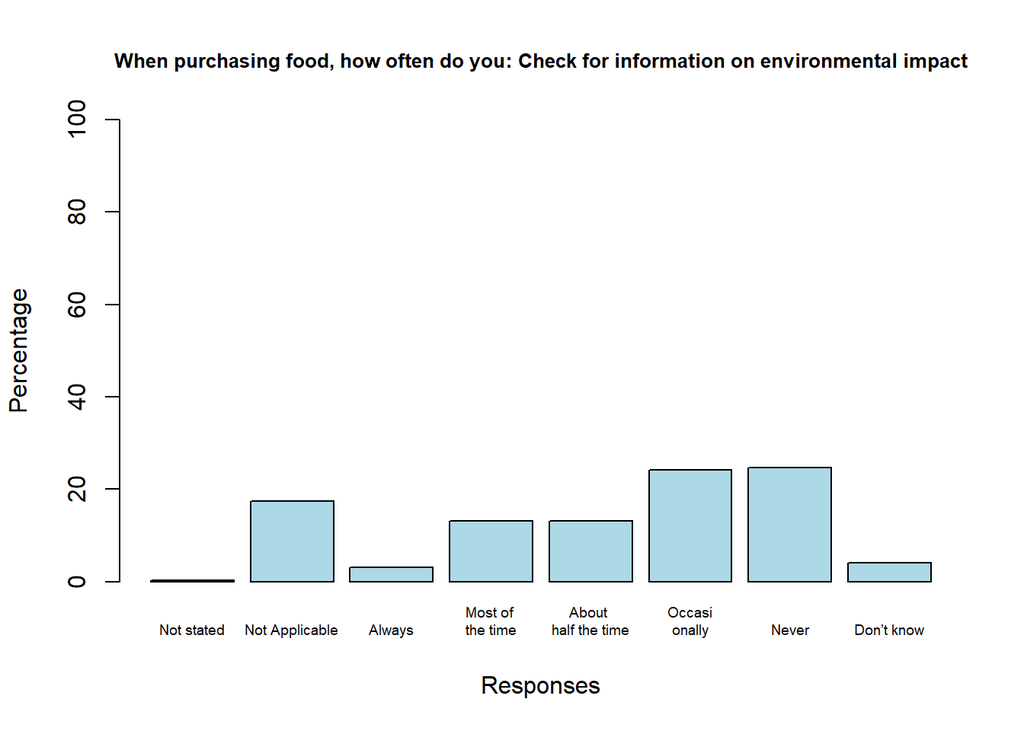

```r
barplot(table(Wave_4$defra4_2)/length(Wave_4$defra4_2) * 100,
        main = "When purchasing food, how often do you: Check for information on environmental impact",
        xlab = "Responses",
        ylab = "Percentage",
        ylim = c(0, 100),
        names.arg = c("Not stated", "Not Applicable", "Always", "Most of \nthe time", "About \nhalf the time", "Occasi\nonally", "Never", "Don’t know"),
        col = "lightblue",
        cex.main=0.8,
        cex.names=0.6)
```

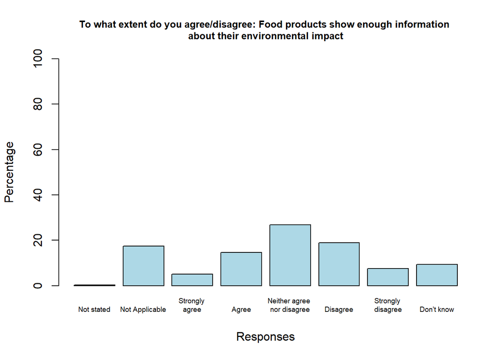

```r
barplot(table(Wave_4$defra5_2)/length(Wave_4$defra5_2) * 100,
        main = "To what extent do you agree/disagree: Food products show enough information \nabout their environmental impact",
        xlab = "Responses",
        ylab = "Percentage",
        ylim = c(0, 100),
        names.arg = c("Not stated", "Not Applicable", "Strongly \nagree", "Agree", "Neither agree \nnor disagree", "Disagree", "Strongly \ndisagree", "Don’t know"),
        col = "lightblue",
        cex.main=0.8,
        cex.names=0.6)
```

## What do you think contributes most to someone having a sustainable diet

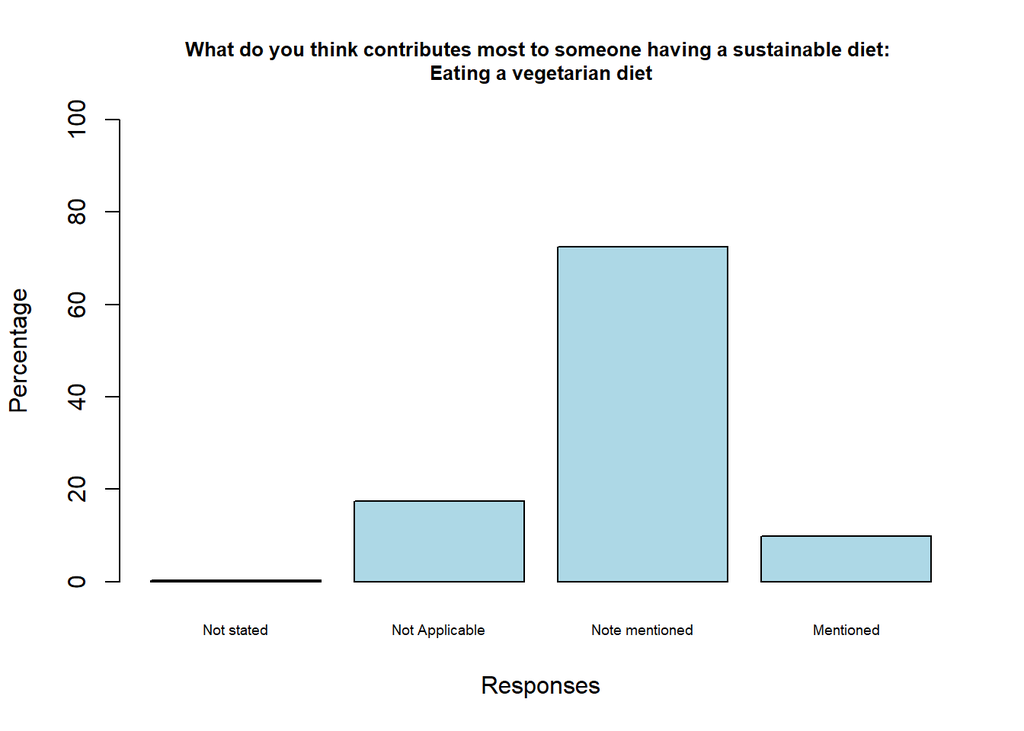

```r
barplot(table(Wave_4$defra11_1)/length(Wave_4$defra11_1) * 100,
        main = "What do you think contributes most to someone having a sustainable diet: \nEating a vegetarian diet",
        xlab = "Responses",
        ylab = "Percentage",
        ylim = c(0, 100),
        names.arg = c("Not stated", "Not Applicable", "Note mentioned", "Mentioned"),
        col = "lightblue",
        cex.main=0.8,
        cex.names=0.6)
```

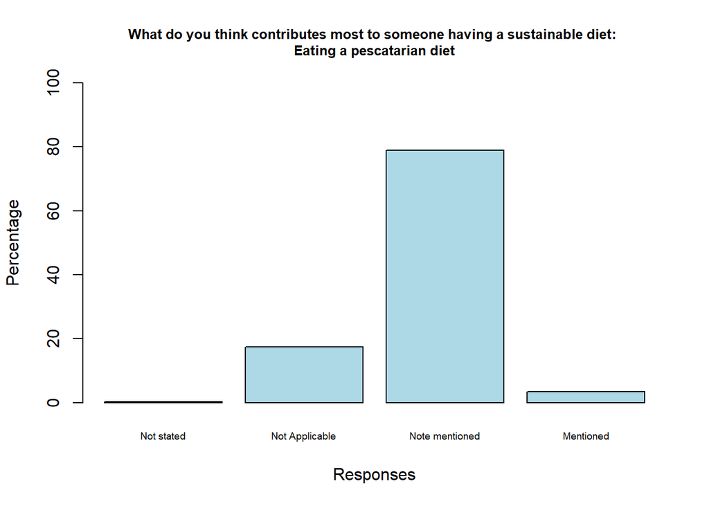

```r
barplot(table(Wave_4$defra11_2)/length(Wave_4$defra11_2) * 100,
        main = "What do you think contributes most to someone having a sustainable diet: \nEating a pescatarian diet",
        xlab = "Responses",
        ylab = "Percentage",
        ylim = c(0, 100),
        names.arg = c("Not stated", "Not Applicable", "Note mentioned", "Mentioned"),
        col = "lightblue",
        cex.main=0.8,
        cex.names=0.6)
```

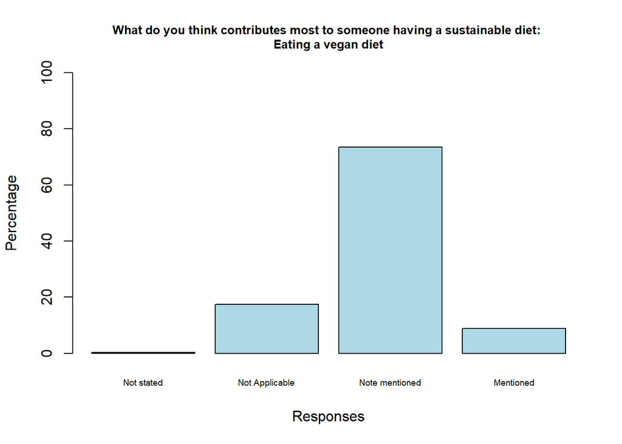

```r
barplot(table(Wave_4$defra11_3)/length(Wave_4$defra11_3) * 100,
        main = "What do you think contributes most to someone having a sustainable diet: \nEating a vegan diet",
        xlab = "Responses",
        ylab = "Percentage",
        ylim = c(0, 100),
        names.arg = c("Not stated", "Not Applicable", "Note mentioned", "Mentioned"),
        col = "lightblue",
        cex.main=0.8,
        cex.names=0.6)
```

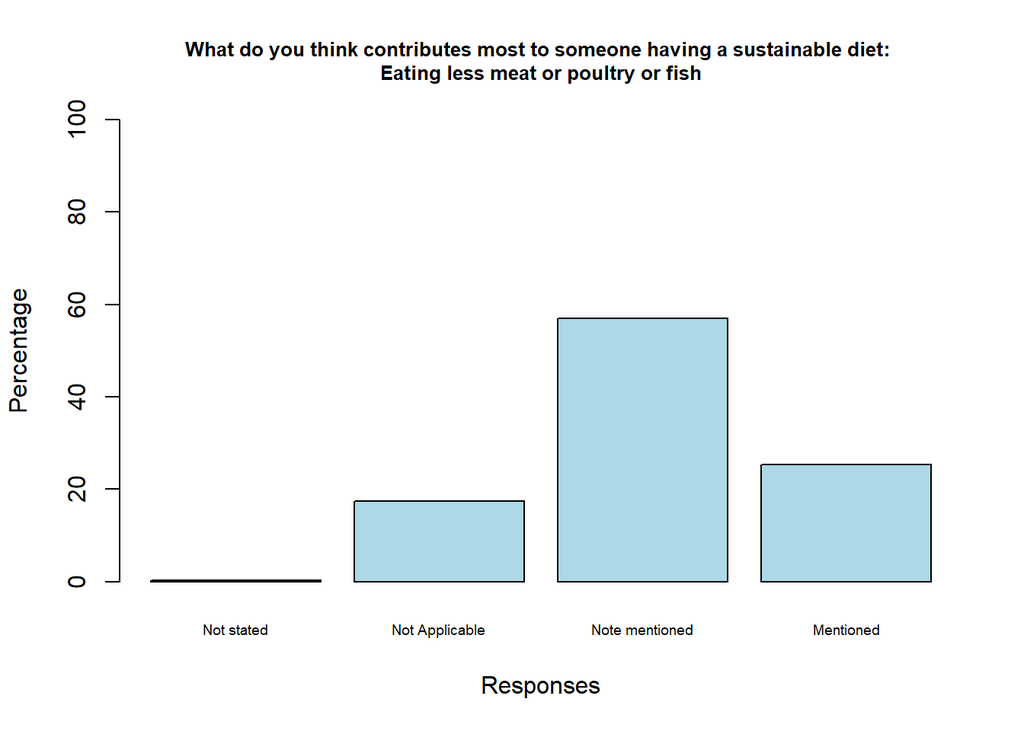

```r
barplot(table(Wave_4$defra11_4)/length(Wave_4$defra11_4) * 100,
        main = "What do you think contributes most to someone having a sustainable diet: \nEating less meat or poultry or fish",
        xlab = "Responses",
        ylab = "Percentage",
        ylim = c(0, 100),
        names.arg = c("Not stated", "Not Applicable", "Note mentioned", "Mentioned"),
        col = "lightblue",
        cex.main=0.8,
        cex.names=0.6)
```

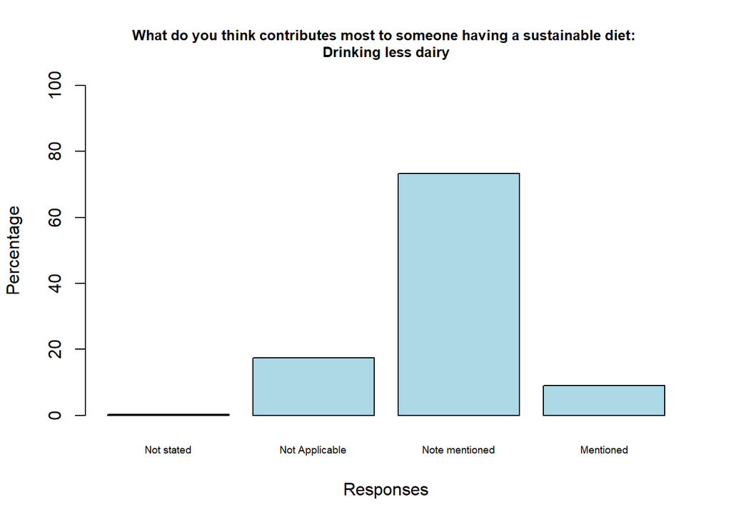

```r
barplot(table(Wave_4$defra11_5)/length(Wave_4$defra11_5) * 100,
        main = "What do you think contributes most to someone having a sustainable diet: \nDrinking less dairy",               xlab = "Responses",
        ylab = "Percentage",
        ylim = c(0, 100),
        names.arg = c("Not stated", "Not Applicable", "Note mentioned", "Mentioned"),
        col = "lightblue",
        cex.main=0.8,
        cex.names=0.6)
```

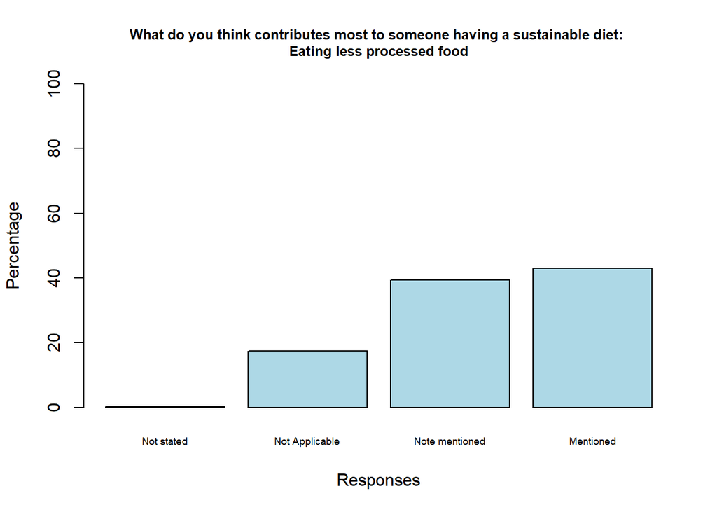

```r
barplot(table(Wave_4$defra11_6)/length(Wave_4$defra11_6) * 100,
        main = "What do you think contributes most to someone having a sustainable diet: \nEating less processed food",
        xlab = "Responses",
        ylab = "Percentage",
        ylim = c(0, 100),
        names.arg = c("Not stated", "Not Applicable", "Note mentioned", "Mentioned"),
        col = "lightblue",
        cex.main=0.8,
        cex.names=0.6)
```

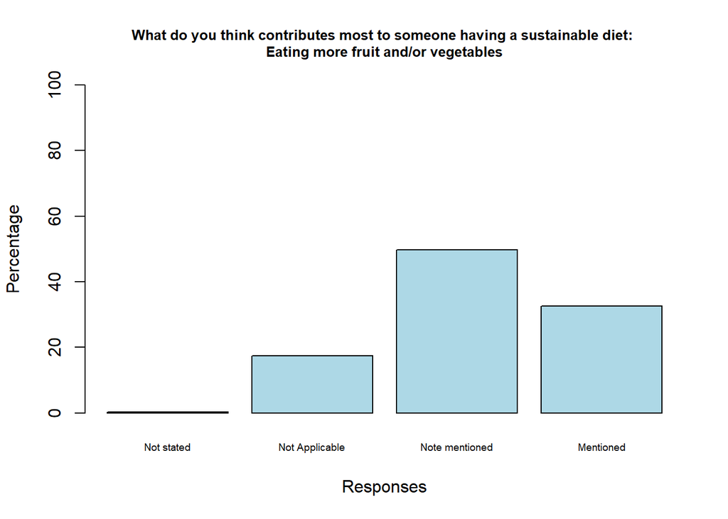

```r
barplot(table(Wave_4$defra11_7)/length(Wave_4$defra11_7) * 100,
        main = "What do you think contributes most to someone having a sustainable diet: \nEating more fruit and/or vegetables",
        xlab = "Responses",
        ylab = "Percentage",
        ylim = c(0, 100),
        names.arg = c("Not stated", "Not Applicable", "Note mentioned", "Mentioned"),
        col = "lightblue",
        cex.main=0.8,
        cex.names=0.6)
```

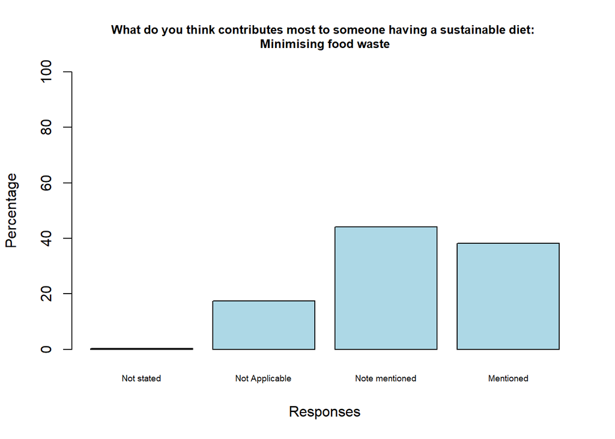

```r
barplot(table(Wave_4$defra11_8)/length(Wave_4$defra11_8) * 100,
        main = "What do you think contributes most to someone having a sustainable diet: \nMinimising food waste",
        xlab = "Responses",
        ylab = "Percentage",
        ylim = c(0, 100),
        names.arg = c("Not stated", "Not Applicable", "Note mentioned", "Mentioned"),
        col = "lightblue",
        cex.main=0.8,
        cex.names=0.6)
```

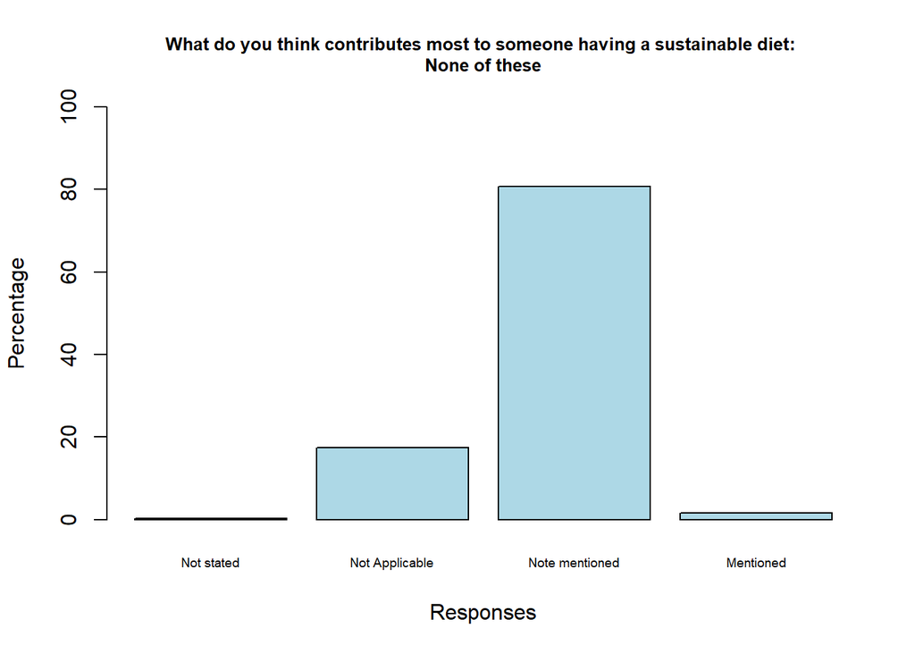

```r
barplot(table(Wave_4$defra11_9)/length(Wave_4$defra11_9) * 100,
        main = "What do you think contributes most to someone having a sustainable diet: \nNone of these",                            xlab = "Responses",
        ylab = "Percentage",
        ylim = c(0, 100),
        names.arg = c("Not stated", "Not Applicable", "Note mentioned", "Mentioned"),
        col = "lightblue",
        cex.main=0.8,
        cex.names=0.6)
```

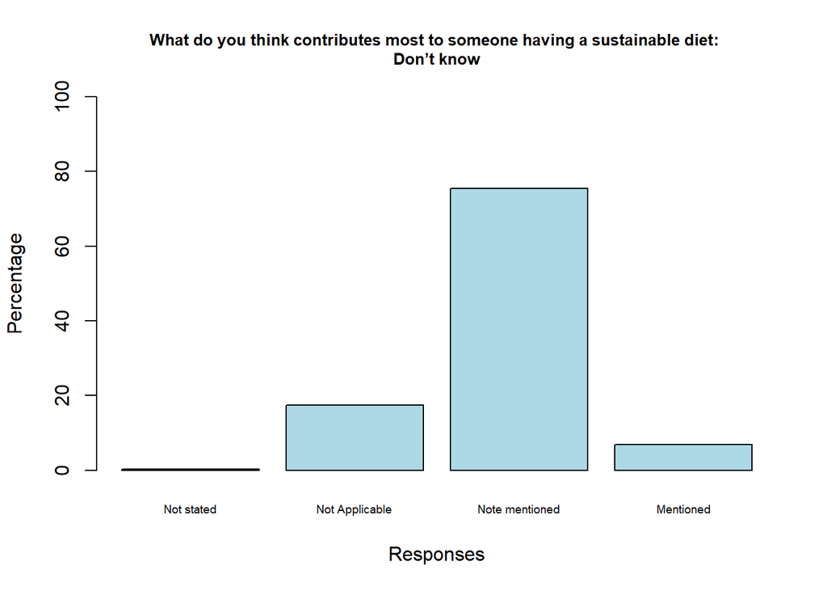

```r
barplot(table(Wave_4$defra11_10)/length(Wave_4$defra11_10) * 100,
        main = "What do you think contributes most to someone having a sustainable diet: \nDon’t know",                               xlab = "Responses",
        ylab = "Percentage",
        ylim = c(0, 100),
        names.arg = c("Not stated", "Not Applicable", "Note mentioned", "Mentioned"),
        col = "lightblue",
        cex.main=0.8,
        cex.names=0.6)
```

## What do you think contributes most to someone making sustainable food shopping choices

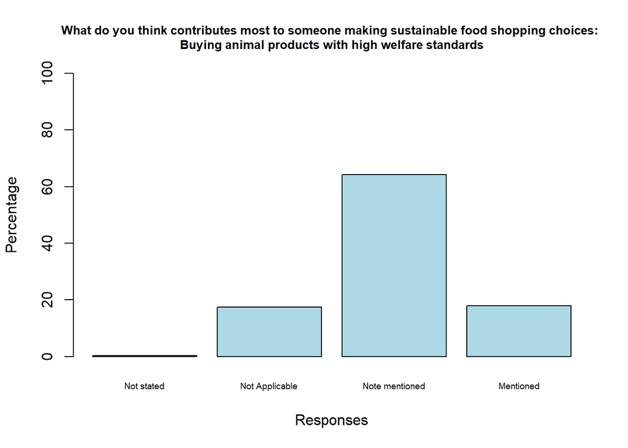

```r
barplot(table(Wave_4$defra12_1)/length(Wave_4$defra12_1) * 100,
        main = "What do you think contributes most to someone making sustainable food shopping choices: \nBuying animal products with high welfare standards",
        xlab = "Responses",
        ylab = "Percentage",
        ylim = c(0, 100),
        names.arg = c("Not stated", "Not Applicable", "Note mentioned", "Mentioned"),
        col = "lightblue",
        cex.main=0.8,
        cex.names=0.6)
```

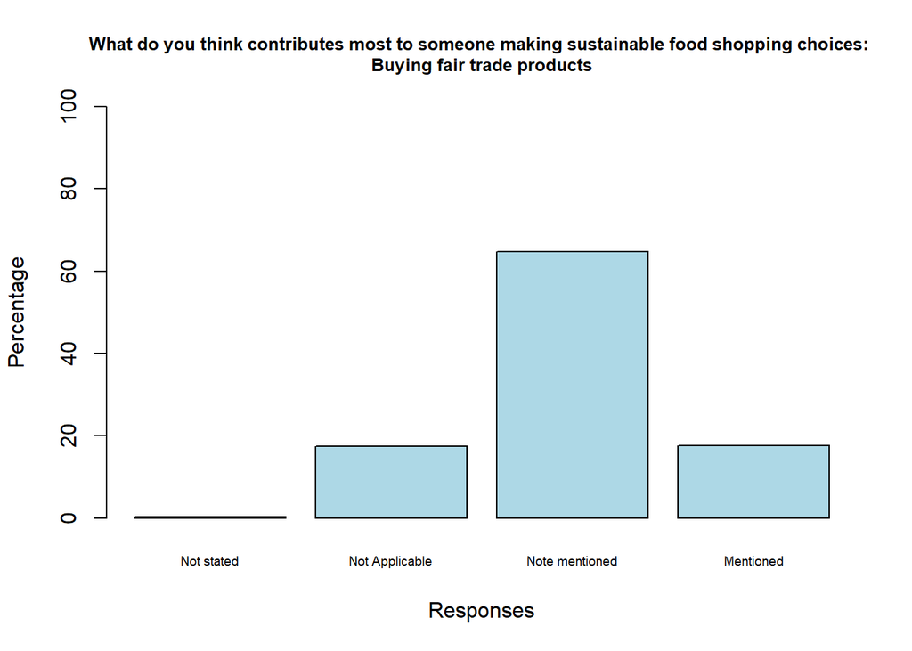

```r
barplot(table(Wave_4$defra12_2)/length(Wave_4$defra12_2) * 100,
        main = "What do you think contributes most to someone making sustainable food shopping choices: \nBuying fair trade products",
        xlab = "Responses",
        ylab = "Percentage",
        ylim = c(0, 100),
        names.arg = c("Not stated", "Not Applicable", "Note mentioned", "Mentioned"),
        col = "lightblue",
        cex.main=0.8,
        cex.names=0.6)
```

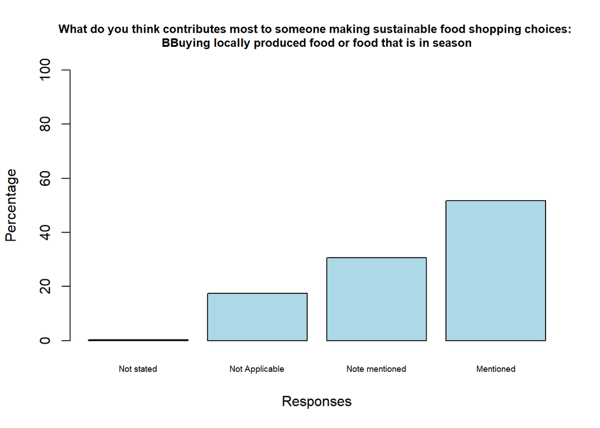

```r
barplot(table(Wave_4$defra12_3)/length(Wave_4$defra12_3) * 100,
        main = "What do you think contributes most to someone making sustainable food shopping choices: \nBBuying locally produced food or food that is in season",
        xlab = "Responses",
        ylab = "Percentage",
        ylim = c(0, 100),
        names.arg = c("Not stated", "Not Applicable", "Note mentioned", "Mentioned"),
        col = "lightblue",
        cex.main=0.8,
        cex.names=0.6)
```

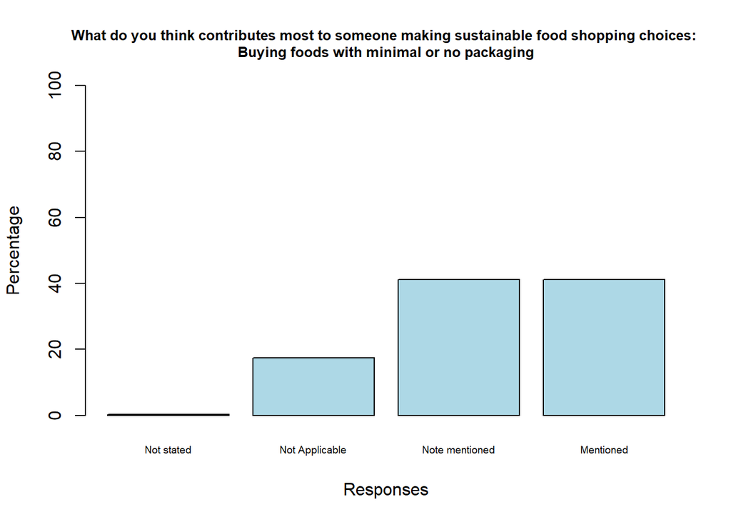

```r
barplot(table(Wave_4$defra12_4)/length(Wave_4$defra12_4) * 100,
        main = "What do you think contributes most to someone making sustainable food shopping choices: \nBuying foods with minimal or no packaging",
        xlab = "Responses",
        ylab = "Percentage",
        ylim = c(0, 100),
        names.arg = c("Not stated", "Not Applicable", "Note mentioned", "Mentioned"),
        col = "lightblue",
        cex.main=0.8,
        cex.names=0.6)
```

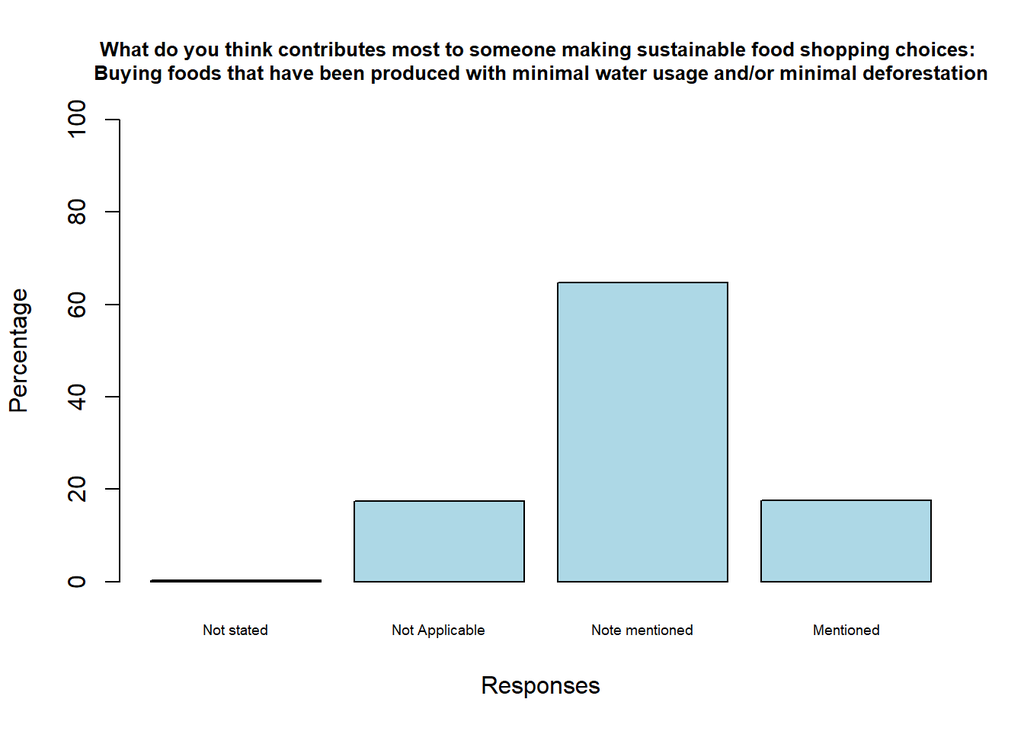

```r
barplot(table(Wave_4$defra12_5)/length(Wave_4$defra12_5) * 100,
        main = "What do you think contributes most to someone making sustainable food shopping choices: \nBuying foods that have been produced with minimal water usage and/or minimal deforestation",
        xlab = "Responses",
        ylab = "Percentage",
        ylim = c(0, 100),
        names.arg = c("Not stated", "Not Applicable", "Note mentioned", "Mentioned"),
        col = "lightblue",
        cex.main=0.8,
        cex.names=0.6)
```

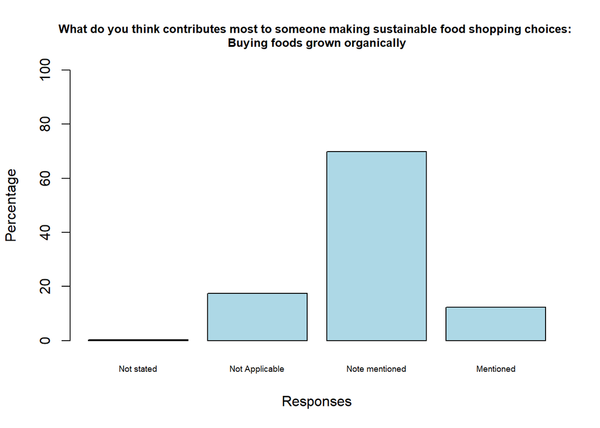

```r
barplot(table(Wave_4$defra12_6)/length(Wave_4$defra12_6) * 100,
        main = "What do you think contributes most to someone making sustainable food shopping choices: \nBuying foods grown organically",
        xlab = "Responses",
        ylab = "Percentage",
        ylim = c(0, 100),
        names.arg = c("Not stated", "Not Applicable", "Note mentioned", "Mentioned"),
        col = "lightblue",
        cex.main=0.8,
        cex.names=0.6)
```

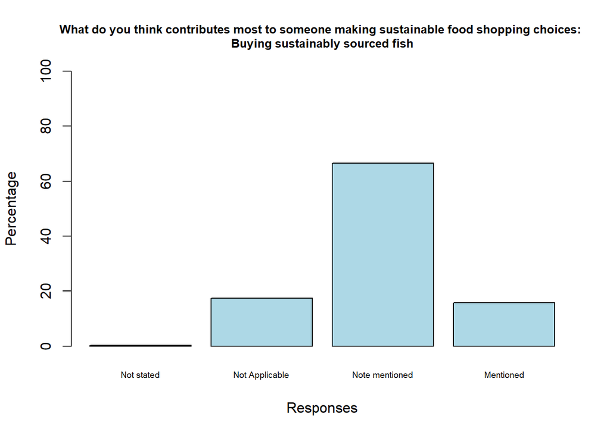

```r
barplot(table(Wave_4$defra12_7)/length(Wave_4$defra12_7) * 100,
        main = "What do you think contributes most to someone making sustainable food shopping choices: \nBuying sustainably sourced fish",
        xlab = "Responses",
        ylab = "Percentage",
        ylim = c(0, 100),
        names.arg = c("Not stated", "Not Applicable", "Note mentioned", "Mentioned"),
        col = "lightblue",
        cex.main=0.8,
        cex.names=0.6)
```

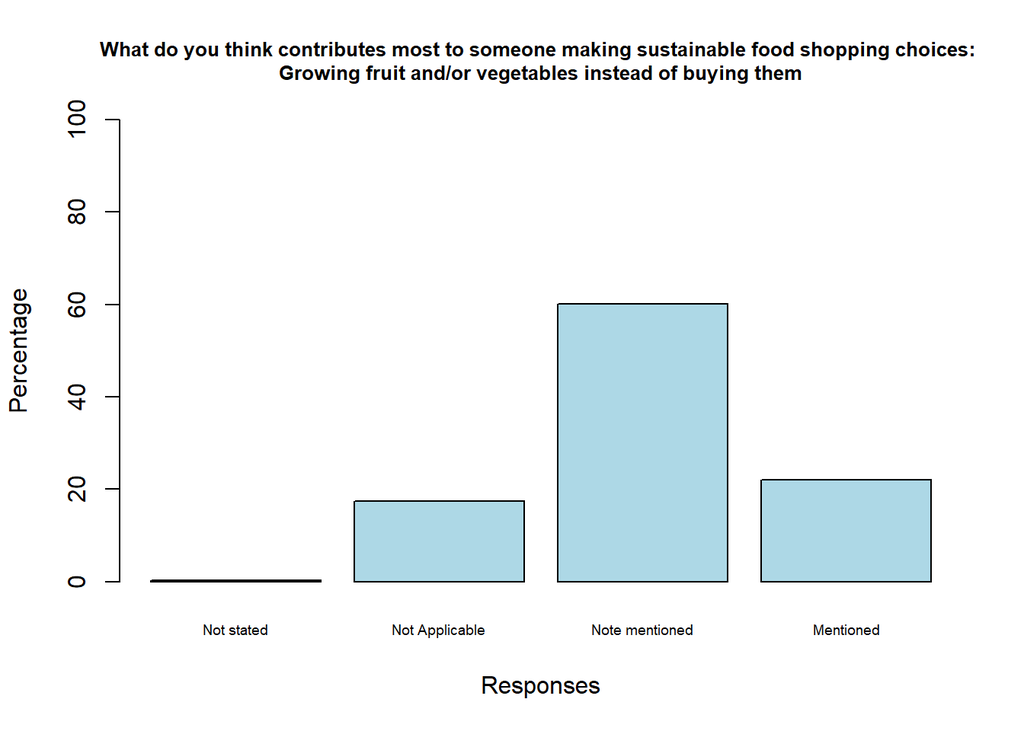

```r
barplot(table(Wave_4$defra12_8)/length(Wave_4$defra12_8) * 100,
        main = "What do you think contributes most to someone making sustainable food shopping choices: \nGrowing fruit and/or vegetables instead of buying them",
        xlab = "Responses",
        ylab = "Percentage",
        ylim = c(0, 100),
        names.arg = c("Not stated", "Not Applicable", "Note mentioned", "Mentioned"),
        col = "lightblue",
        cex.main=0.8,
        cex.names=0.6)
```

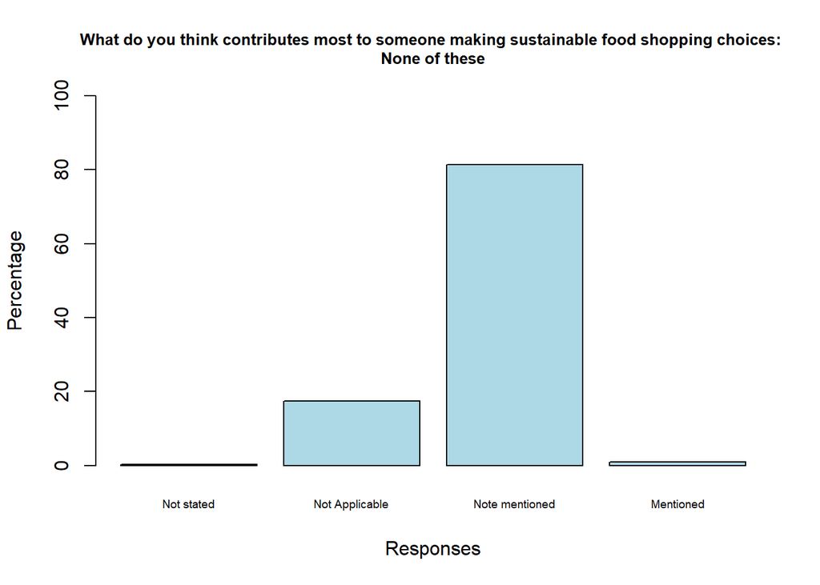

```r
barplot(table(Wave_4$defra12_9)/length(Wave_4$defra12_9) * 100,
        main = "What do you think contributes most to someone making sustainable food shopping choices: \nNone of these",             xlab = "Responses",
        ylab = "Percentage",
        ylim = c(0, 100),
        names.arg = c("Not stated", "Not Applicable", "Note mentioned", "Mentioned"),
        col = "lightblue",
        cex.main=0.8,
        cex.names=0.6)
```

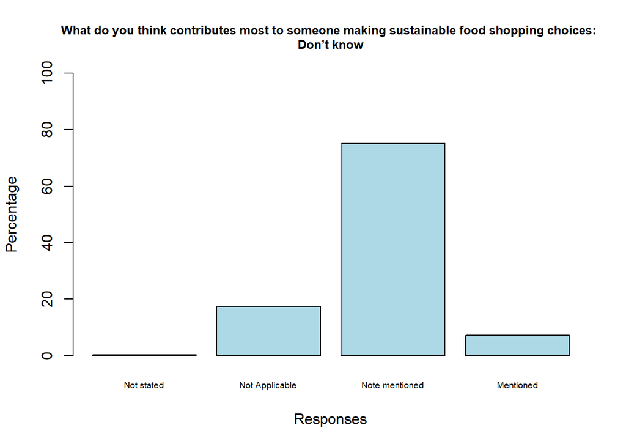

```r
barplot(table(Wave_4$defra12_10)/length(Wave_4$defra12_10) * 100,
        main = "What do you think contributes most to someone making sustainable food shopping choices: \nDon’t know",                xlab = "Responses",
        ylab = "Percentage",
        ylim = c(0, 100),
        names.arg = c("Not stated", "Not Applicable", "Note mentioned", "Mentioned"),
        col = "lightblue",
        cex.main=0.8,
        cex.names=0.6)
```

## Which changes have you made in the last 12 months

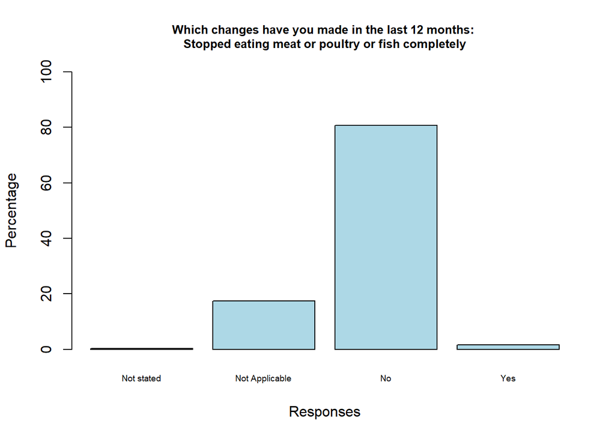

```r
barplot(table(Wave_4$susbehv1)/length(Wave_4$susbehv1) * 100,
        main = "Which changes have you made in the last 12 months: \nStopped eating meat or poultry or fish completely",
        xlab = "Responses",
        ylab = "Percentage",
        ylim = c(0, 100),
        names.arg = c("Not stated", "Not Applicable", "No", "Yes"), #if yes, go to q49
        col = "lightblue",
        cex.main=0.8,
        cex.names=0.6)
```

[figure not shown]

```r
barplot(table(Wave_4$susbehv1)/length(Wave_4$susbehv2) * 100,
        main = "Which changes have you made in the last 12 months: \nEaten less meat or poultry or fish",
        xlab = "Responses",
        ylab = "Percentage",
        ylim = c(0, 100),
        names.arg = c("Not stated", "Not Applicable", "No", "Yes"), #if yes, go to g50
        col = "lightblue",
        cex.main=0.8,
        cex.names=0.6)
```

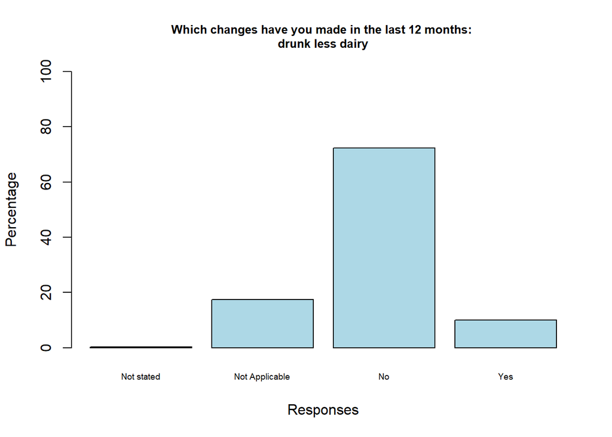

```r
barplot(table(Wave_4$susbehv3)/length(Wave_4$susbehv3) * 100,
        main = "Which changes have you made in the last 12 months: \ndrunk less dairy",
        xlab = "Responses",
        ylab = "Percentage",
        ylim = c(0, 100),
        names.arg = c("Not stated", "Not Applicable", "No", "Yes"), #if yes, go to g51
        col = "lightblue",
        cex.main=0.8,
        cex.names=0.6)
```

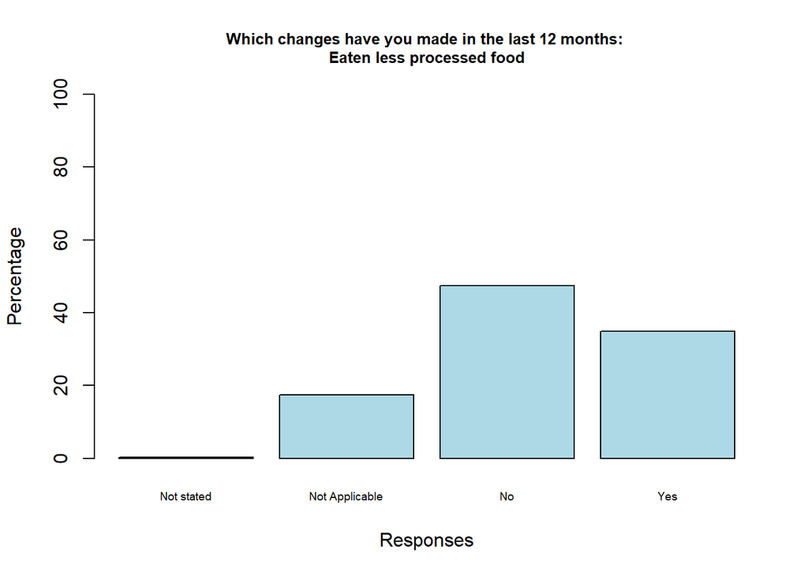

```r
barplot(table(Wave_4$susbehv4)/length(Wave_4$susbehv4) * 100,
        main = "Which changes have you made in the last 12 months: \nEaten less processed food",
        xlab = "Responses",
        ylab = "Percentage",
        ylim = c(0, 100),
        names.arg = c("Not stated", "Not Applicable", "No", "Yes"), #if yes, go to g51
        col = "lightblue",
        cex.main=0.8,
        cex.names=0.6)
```

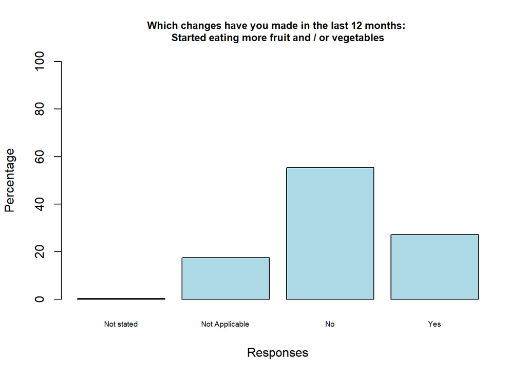

```r
barplot(table(Wave_4$susbehv5)/length(Wave_4$susbehv5) * 100,
        main = "Which changes have you made in the last 12 months: \nStarted eating more fruit and / or vegetables",
        xlab = "Responses",
        ylab = "Percentage",
        ylim = c(0, 100),
        names.arg = c("Not stated", "Not Applicable", "No", "Yes"), #if yes, go to g51
        col = "lightblue",
        cex.main=0.8,
        cex.names=0.6)
```

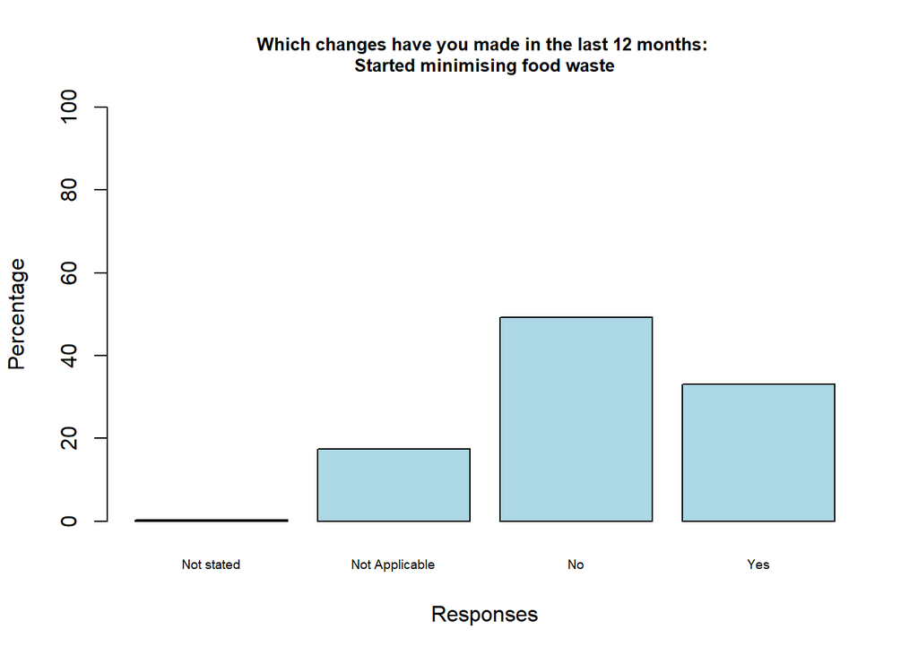

```r
barplot(table(Wave_4$susbehv6)/length(Wave_4$susbehv6) * 100,
        main = "Which changes have you made in the last 12 months: \nStarted minimising food waste",
        xlab = "Responses",
        ylab = "Percentage",
        ylim = c(0, 100),
        names.arg = c("Not stated", "Not Applicable", "No", "Yes"), #if yes, go to g51
        col = "lightblue",
        cex.main=0.8,
        cex.names=0.6)
```

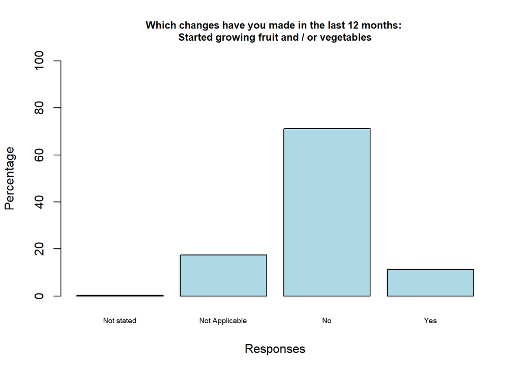

```r
barplot(table(Wave_4$susbehv7)/length(Wave_4$susbehv7) * 100,
        main = "Which changes have you made in the last 12 months: \nStarted growing fruit and / or vegetables",
        xlab = "Responses",
        ylab = "Percentage",
        ylim = c(0, 100),
        names.arg = c("Not stated", "Not Applicable", "No", "Yes"), #if yes, go to g51
        col = "lightblue",
        cex.main=0.8,
        cex.names=0.6)
```